# Water Fectching and Child Development

March 29, 2022

## Methodology

## Project data

### USAID Demographic and Health Surveys (DHS)

- Data from all DHS Modules, 2000-2015
- Household surveys in 28 SSA countries
- Records for 42,266 children, aged 5-14
- Block randomized sampling within country
  - Geographic clusters chosen at random
  - Random sampling among proximate households

## Water fetching times

## Fetching times higher among rural households

> Half of urban HHs walk 3 minutes or less to water. 1 in 3 rural HHs more than 30 minutes away.

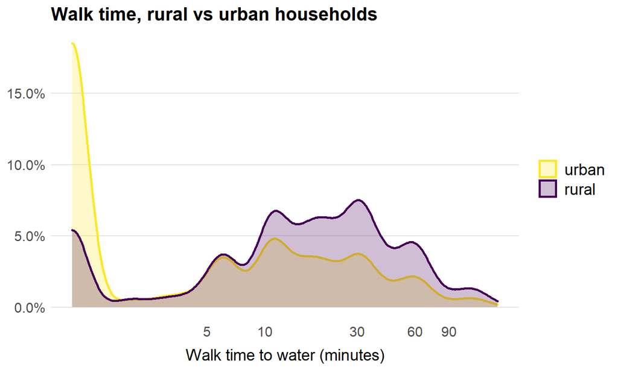

## Wealth buys proximity to water

> Distance to water significantly lower among wealthiest quintiles.

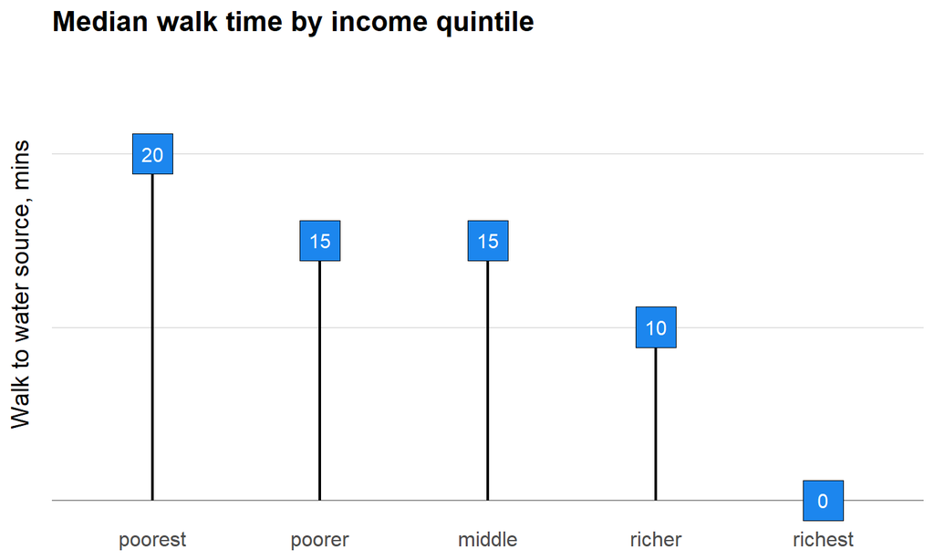

## Water fetching and childhood education

## School attendance invariant to walk time

> Among **urban** HHs, school attendance is slightly higher for boys, but water fetching time is unrelated to attendance for boys or girls.

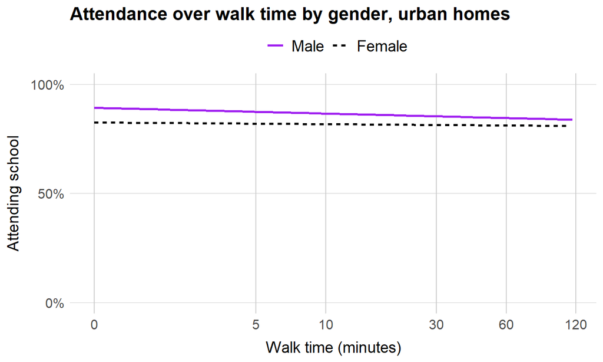

## RMarkdown Reminders

## Setup

### Markdown documents need:

- YAML header
- Setup code chunk
- Body of text

## YAML header

- Specifies title, author, date, etc
- Specifies the output format
- **Spacing/indentation are critical**

```r
---
title: "Water Fectching and Child Development"
subtitle: "Sub-Saharan Africa, 2000-2015"
author: "Austin Hart"
date: "`r format(Sys.time(), '%B %d, %Y')`"
output:
  ioslides_presentation:
    widescreen: true
    css: iostyle.css
---
```

## Setup chunk

- Defines behavior for ALL other code chunks
- **Must** come first
- Label explicitly as `setup`

````
```{r setup, include=FALSE}
  options(htmltools.dir.version = FALSE)
  knitr::opts_chunk$set(
    message=FALSE, warning=FALSE, eval=TRUE, echo=FALSE,
    fig.align='center'
  )
```
````

## Body of doc/deck

Everything else is a combo of text and `R` code chunks.

Remember:

- Code chunks require *unique* names
- `Knit` often to diagnose errors
- Explore different outputs, esp. `Beamer` (requires `tinytex`)